# Project Report: Predicting Feedback Type of Mice Using Brain Activity

Kian Ghaffari - 919740228

06/12/2023

```r
knitr::opts_chunk$set(echo = FALSE)
```

### Abstract

In this project, we began by creating and examining visualizations of the session data to identify trends and correlations. This helped me build an integration model. Using this model, we developed a logistic regression model for prediction. Finally, we used test data provided to test the accuracy of the logistic regression model through the use of misclassificaiton error rate.

### Section 1: Introduction

The main goal of this project is to create a prediction model that can precisely predict the feedback type for each trial using the brain activity data, more especially the spike trains in the “spks” variable, together with the information about the left and right contrasts in the stimuli. The decision-making, action, and engagement processes seen in mice are the focus of this predictive model, which tries to offer insightful explanations. The study “Distributed coding of choice, action, and engagement across the mouse brain” looks into the neurological underpinnings of these processes in order to accomplish this goal. The study analyzes patterns of neuronal activity across multiple brain regions throughout diverse behavioral tasks by using calcium imaging techniques. The study’s findings show that, as opposed to being confined to a single part of the brain, the representation of choice, action, and engagement is dispersed over several brain regions. The study also highlights the variety of neuronal responses within each brain area and task-specific patterns of brain activity that correspond with various behavioral activities. Particularly, the prefrontal cortex, which is recognized for its participation in higher-order cognitive processes, is crucial in the encoding of signals related to action and decision. The study also reveals the temporal dynamics of neural coding, which shows how changes in brain activity patterns occur over time as tasks advance.Overall, this project, in conjunction with the study, aims to provide comprehensive insights into the distributed nature of neural coding and the coordinated engagement of different brain regions in mice’s decision-making, behavior, and engagement processes.

### Section 2: Exploratory Analysis

| mouse_name | date_exp | num_brain_area | num_neurons | num_trials | success_rate |
| --- | --- | --- | --- | --- | --- |
| Cori | 2016-12-14 | 8 | 734 | 114 | 0.61 |
| Cori | 2016-12-17 | 5 | 1070 | 251 | 0.63 |
| Cori | 2016-12-18 | 11 | 619 | 228 | 0.66 |
| Forssmann | 2017-11-01 | 11 | 1769 | 249 | 0.67 |
| Forssmann | 2017-11-02 | 10 | 1077 | 254 | 0.66 |
| Forssmann | 2017-11-04 | 5 | 1169 | 290 | 0.74 |
| Forssmann | 2017-11-05 | 8 | 584 | 252 | 0.67 |
| Hench | 2017-06-15 | 15 | 1157 | 250 | 0.64 |
| Hench | 2017-06-16 | 12 | 788 | 372 | 0.69 |
| Hench | 2017-06-17 | 13 | 1172 | 447 | 0.62 |
| Hench | 2017-06-18 | 6 | 857 | 342 | 0.80 |
| Lederberg | 2017-12-05 | 12 | 698 | 340 | 0.74 |
| Lederberg | 2017-12-06 | 15 | 983 | 300 | 0.80 |
| Lederberg | 2017-12-07 | 10 | 756 | 268 | 0.69 |
| Lederberg | 2017-12-08 | 8 | 743 | 404 | 0.76 |
| Lederberg | 2017-12-09 | 6 | 474 | 280 | 0.72 |
| Lederberg | 2017-12-10 | 6 | 565 | 224 | 0.83 |
| Lederberg | 2017-12-11 | 10 | 1090 | 216 | 0.81 |

Looking at the table above, it can be observed that this includes a summary of all the sessions as well as the number of variables. Variables listed include:mouse_name,date_exp, num_neurons, num_trials, num_brain_areas, and success_rate. The three variables with “num” in their name refer to the variable counting how many of the given variable exist in the session. The variables mouse_name and date_exp refer to the name of the mouse used for the session and the date the experiment occurred. Finally, the success_rate refers to the percentage of trials led to a successful activity by the mouse.

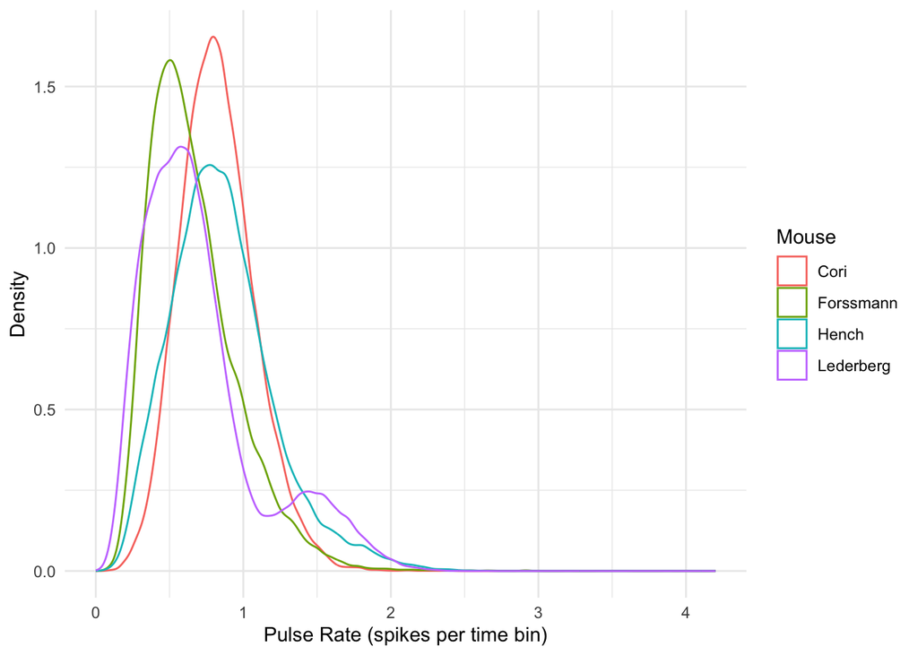

Here we have a Density graph of Pulse Rate for each mouse from the 18 sessions. The graph is pretty clear in stating that the pulse rate, when varying by mouse name, does not clearly impact the data by much. As a result, this will not be used for our integration, although it does give insight to the homogeneity of pulse rate between the 4 mice in the trials.

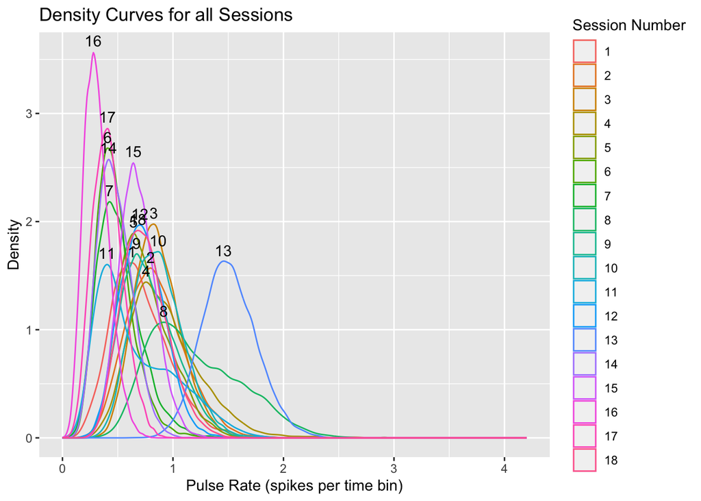

We generated a Density vs Pulse rate chart to compare the 18 sessions. The pulse rate represents the average spikes per time bin, reflecting the average number of neuron firings recorded within a specific time interval across all trials in a session. Overall, the sessions exhibit an average pulse rate around or below 1. However, session 13 stands out as a clear outlier with a significantly higher pulse rate compared to the rest. It appears distinctly separated from the other sessions on the graph. Additionally, sessions 16, 17, 6, and 14 also deviate from the norm, displaying a low pulse rate but a high density. These unique patterns differ from the majority of the data. This graph plays a vital role in our integration process as it allows us to observe the distribution of pulse rate and utilize it as a predictor. It provides valuable insights into the expected pulse rate in relation to the density, which is crucial for our integration analysis.

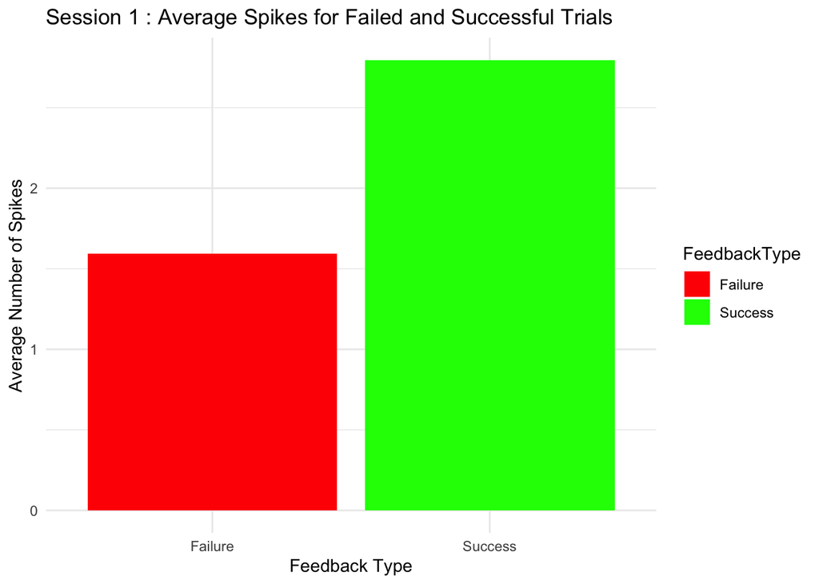

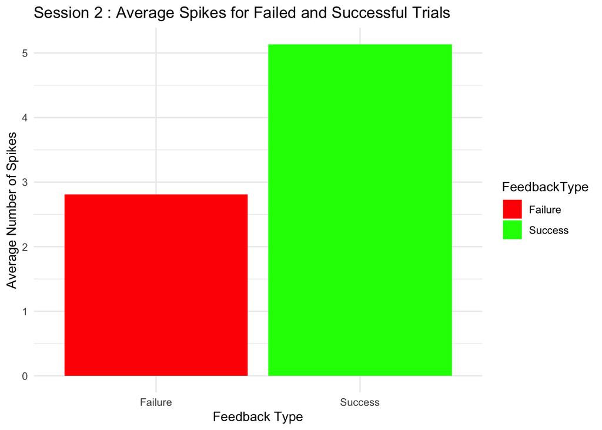

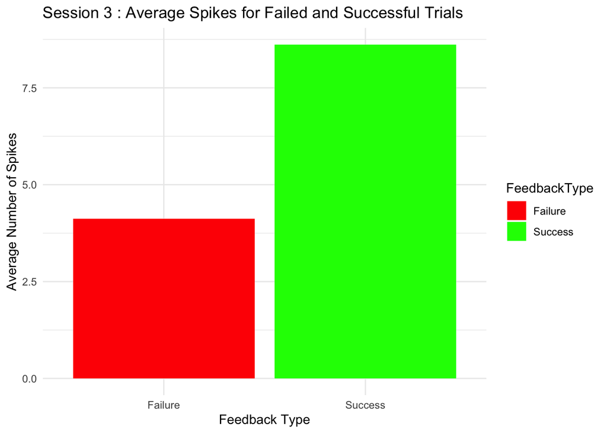

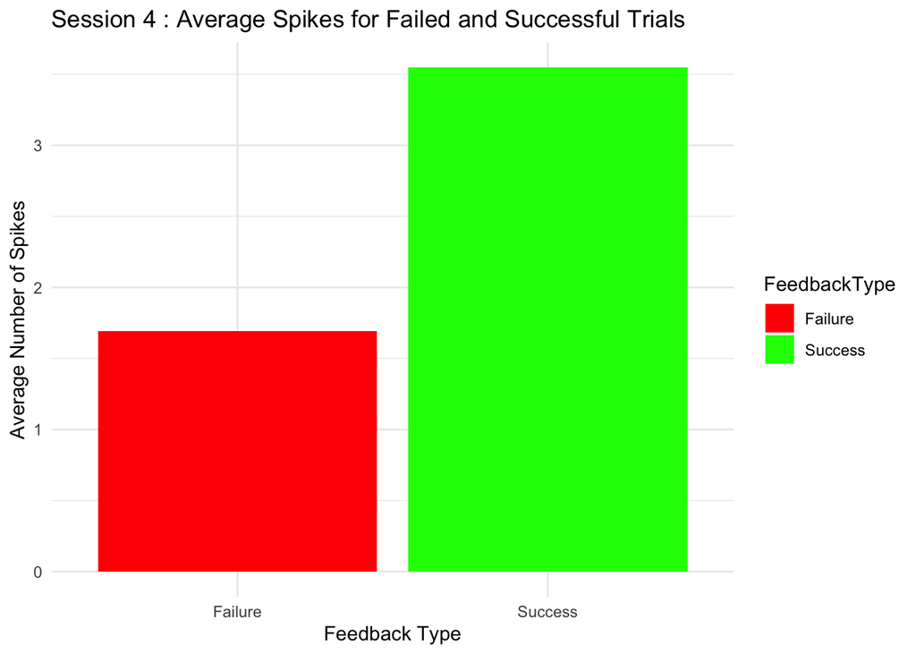

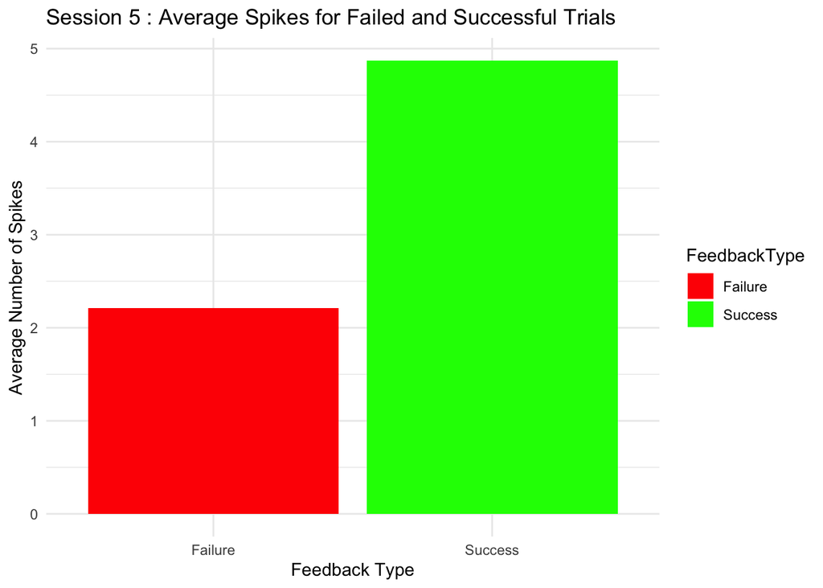

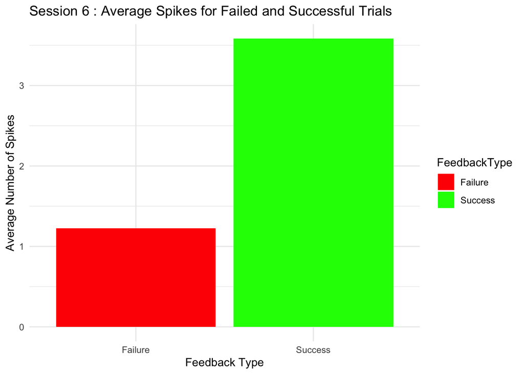

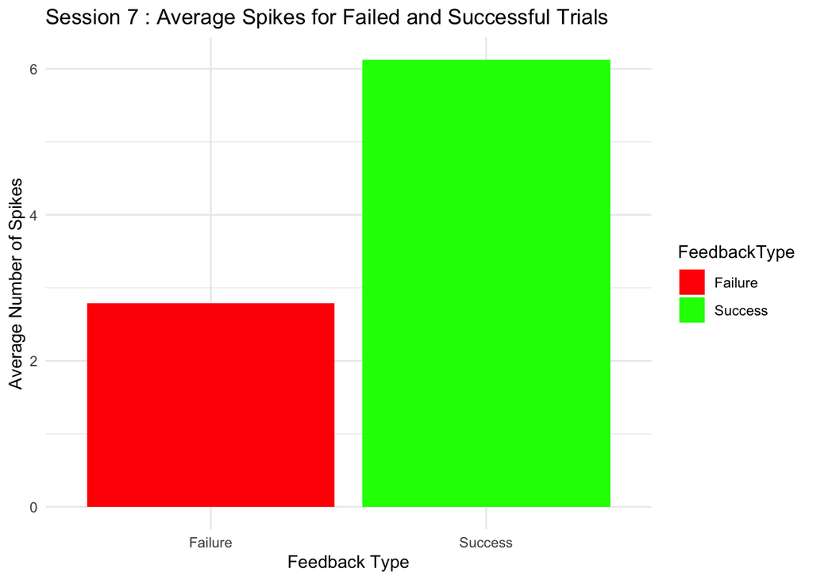

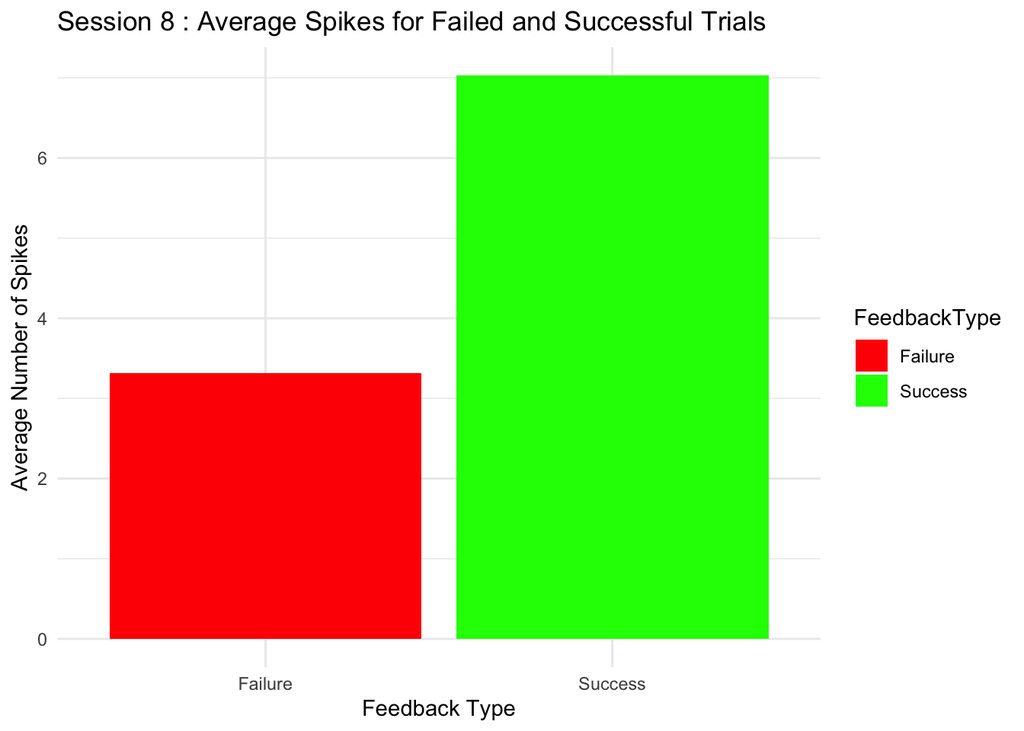

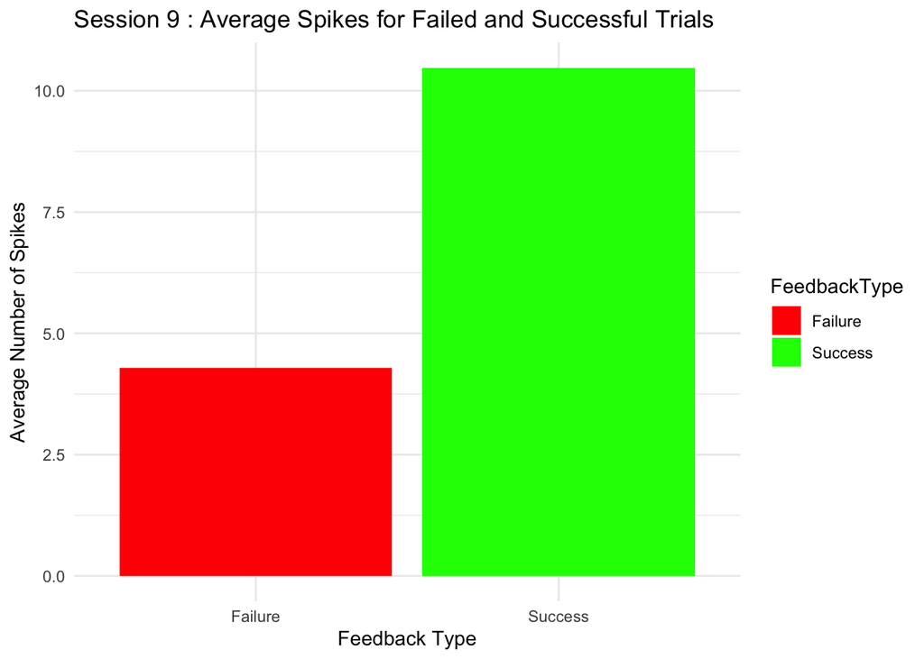

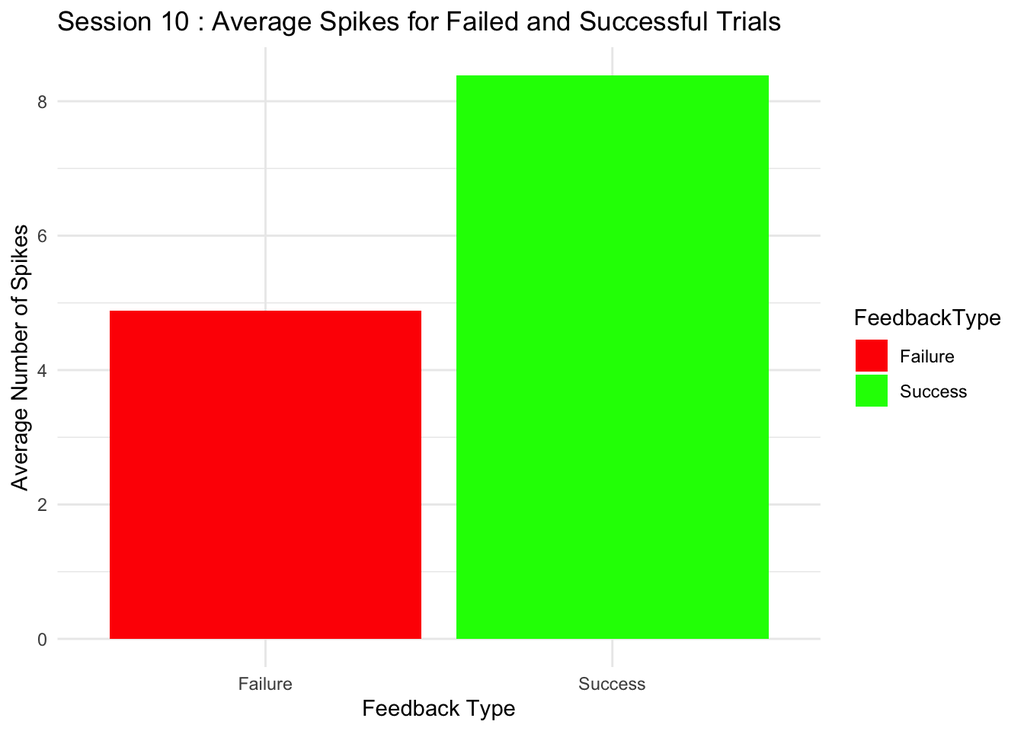

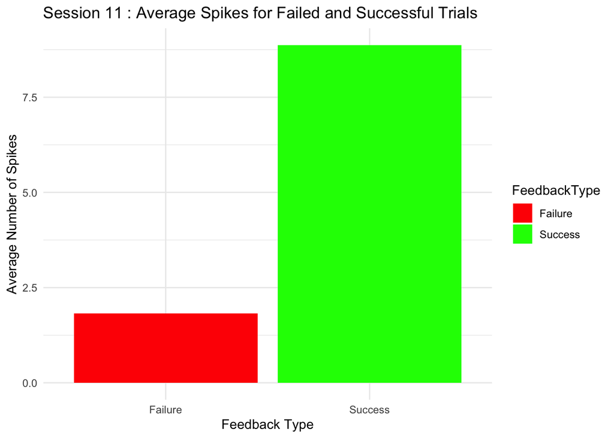

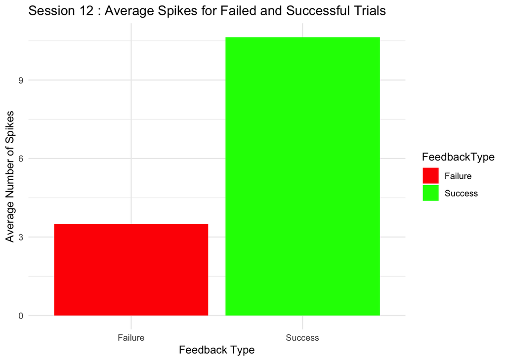

[6 more figures not shown]

[figure not shown]

### Section 3 Data integration.

```
##      CA1       DG       LP       MG      MRN       NB     POST     root
## 2.738095 4.058824 4.500000 2.722628 5.634146 1.674419 1.111111 1.166667
##      SPF    VISam     VISp
## 4.600000 2.061404 1.324561
```

To get started with integrating the data, we had to combine all the sessions into one big dataset. We went through each session and considered every type of feedback. In each session, we calculated the average spike value for each trial. We also looked at the pulse rate and density because we noticed they were related to how well the experiment went, based on our initial analysis. After crunching the numbers, we turned everything into a neat data frame. This way, we can use the data to build a prediction model.

### Section 4 Predictive modeling.

```
##
## Call:
## glm(formula = feedback_type ~ spks_max + pulse_rate + avg_spikes_per_trial +
##     pulse_rate_vs_density, family = binomial(), data = session_all_df)
##
## Deviance Residuals:
##     Min       1Q   Median       3Q      Max
## -1.9591  -1.4487   0.7785   0.8606   1.0059
##
## Coefficients: (1 not defined because of singularities)
##                         Estimate Std. Error z value Pr(>|z|)
## (Intercept)            1.816e-01  1.412e-01   1.286    0.198
## spks_max              -1.658e-03  3.772e-02  -0.044    0.965
## pulse_rate             8.580e+02  1.106e+02   7.760 8.46e-15 ***
## avg_spikes_per_trial          NA         NA      NA       NA
## pulse_rate_vs_density -9.763e-05  6.759e-04  -0.144    0.885
## ---
## Signif. codes:  0 '***' 0.001 '**' 0.01 '*' 0.05 '.' 0.1 ' ' 1
##
## (Dispersion parameter for binomial family taken to be 1)
##
##     Null deviance: 6118.2  on 5080  degrees of freedom
## Residual deviance: 6050.6  on 5077  degrees of freedom
## AIC: 6058.6
##
## Number of Fisher Scoring iterations: 4
```

With the data frame, a logistic or general linear model was created as the prediction model. This will also be the model that we use to predict the missing values in sessions 1 and 18.

### Section 5: Prediction performance on the test sets.

| mouse_name | date_exp | n_brain_area | n_neurons | n_trials | success_rate |
| --- | --- | --- | --- | --- | --- |
| Cori | 2016-12-14 | 8 | 734 | 100 | 0.72 |
| Lederberg | 2017-12-11 | 10 | 1090 | 100 | 0.73 |

Now we begin to add test data that had been removed from the original data in order to test the accuracy of our newly-made prediction model.

The table above includes only missing values from sessions 1 and 18.

```
## [1] "Misclassification Rate:  0.275"
```

# Code Appendix

```r
knitr::opts_chunk$set(echo = FALSE)
suppressWarnings(library(tidyverse))
suppressWarnings(library(knitr))
suppressWarnings(library(dplyr))
setwd("/Users/kianghaffari/Documents/Sessions")

session=list()
for(i in 1:18){
  session[[i]]=readRDS(paste('/Users/kianghaffari/Documents/Sessions/session',i,'.rds',sep=''))
   #print(session[[i]]$mouse_name)
   #print(session[[i]]$date_exp)

}

n.session=length(session)

meta <- tibble(
  mouse_name = rep('name',n.session),
  date_exp =rep('dt',n.session),
  num_brain_area = rep(0,n.session),
  num_neurons = rep(0,n.session),
  num_trials = rep(0,n.session),
  success_rate = rep(0,n.session)
)


for(i in 1:n.session){
  tmp = session[[i]];
  meta[i,1]=tmp$mouse_name;
  meta[i,2]=tmp$date_exp;
  meta[i,3]=length(unique(tmp$brain_area));
  meta[i,4]=dim(tmp$spks[[1]])[1];
  meta[i,5]=length(tmp$feedback_type);
  meta[i,6]=mean(tmp$feedback_type+1)/2;
  }

kable(meta, format = "html", table.attr = "class='table table-striped'",digits=2)

density_data <- data.frame()

for (i in 1:18) {
  session_data <- session[[i]]$spks

  pulse_rates <- lapply(session_data, function(trial) colSums(trial)/ncol(trial))

  pulse_rates <- unlist(pulse_rates)


  density_data <- rbind(density_data,
                        data.frame(Mouse = session[[i]]$mouse_name,
                                   PulseRate = pulse_rates))
}

# Density plot
ggplot(density_data, aes(x = PulseRate, color = as.factor(Mouse))) +
  geom_density(alpha = 0.4) +
  labs(x = "Pulse Rate (spikes per time bin)",
       y = "Density",
       color = "Mouse") +
  theme_minimal() +
  guides(color = guide_legend(override.aes = list(alpha = 1)))
for (i in 1:18) {
  # Select session data
  session_data <- session[[i]]$spks

  # Calculate pulse rates (spikes per time bin) for each trial
  pulse_rates <- lapply(session_data, function(trial) colSums(trial)/ncol(trial))

  # Convert list to vector
  pulse_rates <- unlist(pulse_rates)

  # Create density plot
  p <- ggplot(data.frame(PulseRate = pulse_rates), aes(x = PulseRate)) +
    geom_density( color = "black") +
    labs(x = "Pulse Rate (spikes per time bin)", y = "Density",
         title = paste("Session", i))

}

# Initialize an empty data frame to store all sessions' data
all_data <- data.frame()

# Loop over all sessions
for (i in 1:18) {
  # Select session data
  session_data <- session[[i]]$spks

  # Calculate pulse rates (spikes per time bin) for each trial
  pulse_rates <- lapply(session_data, function(trial) colSums(trial)/ncol(trial))

  # Convert list to vector
  pulse_rates <- unlist(pulse_rates)

  # Convert pulse rates to a data frame and add session number
  pulse_rates <- data.frame(PulseRate = pulse_rates, Session = rep(i, length(pulse_rates)))

  # Add to the overall data frame
  all_data <- rbind(all_data, pulse_rates)
}

# Calculate maximum density positions
max_density_positions <- all_data %>%
  group_by(Session) %>%
  do(data.frame(MaxDensPos = with(density(.$PulseRate), x[which.max(y)]),
                MaxDens = with(density(.$PulseRate), max(y))))

# Create overlaid density plot
p <- ggplot(all_data, aes(x = PulseRate, color = as.factor(Session))) +
  geom_density() +
   geom_text(data = max_density_positions,
            aes(x = MaxDensPos, y = MaxDens, label = Session),
            color = "black", vjust = -0.5) +
  labs(x = "Pulse Rate (spikes per time bin)", y = "Density",
       title = "Density Curves for all Sessions",
       color = "Session Number")

# Print the plot
print(p)
# Create a list to store all plots
plots <- list()

# Loop through all sessions
for (j in 1:18) {

  # Select session data
  session_data <- session[[j]]

  # Group trials by feedback type
  grouped_data <- split(session_data$spks, session_data$feedback_type)

  # Calculate average number of spikes for each group
  avg_spikes <- lapply(grouped_data, function(trials) {
    sapply(trials, function(trial) mean(unlist(trial)))
  })

  # Convert list to a data frame
  avg_spikes_df <- data.frame(
    FeedbackType = rep(c("Failure", "Success"), sapply(avg_spikes, length)),
    AvgSpikes = unlist(avg_spikes)
  )

  # Create a bar chart and add it to the list of plots
  p <- ggplot(avg_spikes_df, aes(x = FeedbackType, y = AvgSpikes, fill = FeedbackType)) +
    geom_col() +
    scale_fill_manual(values = c("Failure" = "red", "Success" = "green")) +
    labs(x = "Feedback Type", y = "Average Number of Spikes",
         title = paste("Session", j, ": Average Spikes for Failed and Successful Trials")) +
    theme_minimal()

  # Add the plot to the list
  plots[[j]] <- p
}

# Print all plots
for (plot in plots) {
  print(plot)
}
df_success_rate <- data.frame()

for(i in 1:18){
  mouse_name = session[[i]]$mouse_name
  total_trials = length(session[[i]]$feedback_type)
  success_rate = sum(session[[i]]$feedback_type == 1) / total_trials * 10
  df_success_rate = rbind(df_success_rate, data.frame(Mouse = mouse_name, SuccessRate = success_rate))
}

ggplot(df_success_rate, aes(x = Mouse, y = SuccessRate)) +
  geom_bar(stat = "identity", fill = "skyblue") +
  ggtitle("Success Rate per Mouse") +
  xlab("Mouse") +
  ylab("Success Rate (%)") +
  theme_minimal()


i.s=3

i.t=1

spk.trial = session[[i.s]]$spks[[i.t]]
area=session[[i.s]]$brain_area

spk.count=apply(spk.trial,1,sum)




spk.average.tapply=tapply(spk.count, area, mean)



tmp <- data.frame(
  area = area,
  spikes = spk.count
)
spk.average.dplyr =tmp %>%
  group_by(area) %>%
  summarize(mean= mean(spikes))


average_spike_area<-function(i.t,this_session){
  spk.trial = this_session$spks[[i.t]]
  area= this_session$brain_area
  spk.count=apply(spk.trial,1,sum)
  spk.average.tapply=tapply(spk.count, area, mean)
  return(spk.average.tapply)
  }

average_spike_area(1,this_session = session[[i.s]])
n.trial=length(session[[i.s]]$feedback_type)
n.area=length(unique(session[[i.s]]$brain_area ))


trial.summary =matrix(nrow=n.trial,ncol= n.area+1+2+1)
for(i.t in 1:n.trial){
  trial.summary[i.t,]=c(average_spike_area(i.t,this_session = session[[i.s]]),
                          session[[i.s]]$feedback_type[i.t],
                        session[[i.s]]$contrast_left[i.t],
                        session[[i.s]]$contrast_right[i.s],
                        i.t)
}
session_summary <- list()

for (i in 1:18) {
  # Loop over each trial in the current session
  for (j in 1:length(session[[i]]$feedback_type)) {
    # Compute summary statistics for the current trial
    spks_values <- c(session[[i]]$spks[[j]])
    spks_mean <- mean(spks_values)
    spks_sd <- sd(spks_values)
    spks_min <- min(spks_values)
    spks_max <- max(spks_values)

    # Calculate pulse rate (average spikes per time bin)
    pulse_rate <- spks_mean / ncol(session[[i]]$spks[[j]])



    avg_spikes_per_neuron <- mean(rowSums(session[[i]]$spks[[j]]))


avg_spikes_per_trial <- mean(session[[i]]$spks[[j]])

    avg_spikes_per_feedback <- mean(session[[i]]$spks[[j]]) * session[[i]]$feedback_type[j]


    pulse_rate_vs_density <- pulse_rate / density(spks_values)$x[which.max(density(spks_values)$y)]


    avg_spikes_per_neuron_vs_density <- avg_spikes_per_neuron / density(spks_values)$x[which.max(density(spks_values)$y)]


    avg_spikes_per_trial_vs_density <- avg_spikes_per_trial / density(spks_values)$x[which.max(density(spks_values)$y)]


    session_summary[[length(session_summary) + 1]] <- data.frame(
      session_number = i,
      feedback_type = session[[i]]$feedback_type[j],
      contrast_left = session[[i]]$contrast_left[j],
      contrast_right = session[[i]]$contrast_right[j],
      spks_mean = spks_mean,
      spks_sd = spks_sd,
      spks_max = spks_max,
      pulse_rate = pulse_rate,
      avg_spikes_per_neuron = avg_spikes_per_neuron,
      avg_spikes_per_trial = avg_spikes_per_trial,
      avg_spikes_per_feedback = avg_spikes_per_feedback,
      pulse_rate_vs_density = pulse_rate_vs_density,
      avg_spikes_per_neuron_vs_density = avg_spikes_per_neuron_vs_density,
      avg_spikes_per_trial_vs_density = avg_spikes_per_trial_vs_density
    )
  }
}


session_all_df <- do.call(rbind, session_summary)

session_all_df$feedback_type <- (session_all_df$feedback_type + 1) / 2

logistic_model <- glm(feedback_type ~  spks_max + pulse_rate  +
                      avg_spikes_per_trial + pulse_rate_vs_density,
                      data = session_all_df, family = binomial())

summary(logistic_model)

setwd("/Users/kianghaffari/Documents/Tests")
test=list()
for(i in 1:2){
  test[[i]]=readRDS(paste('/Users/kianghaffari/Documents/Tests/test',i,'.rds',sep=''))
}


n.test=length(test)

meta <- tibble(
  mouse_name = rep('name',n.test),
  date_exp =rep('dt',n.test),
  n_brain_area = rep(0,n.test),
  n_neurons = rep(0,n.test),
  n_trials = rep(0,n.test),
  success_rate = rep(0,n.test)
)


for(i in 1:n.test){
  tmp = test[[i]];
  meta[i,1]=tmp$mouse_name;
  meta[i,2]=tmp$date_exp;
  meta[i,3]=length(unique(tmp$brain_area));
  meta[i,4]=dim(tmp$spks[[1]])[1];
  meta[i,5]=length(tmp$feedback_type);
  meta[i,6]=mean(tmp$feedback_type+1)/2;
}


kable(meta, format = "html", table.attr = "class='table table-striped'",digits=2)


# Preprocess test datasets
test_summary <- list()

# length of test
test_length <- length(test)

for (i in 1:test_length) {
  for (j in 1:length(test[[i]]$feedback_type)) {
    # Compute summary statistics for test data
    spks_values <- c(test[[i]]$spks[[j]])
    spks_mean <- mean(spks_values)
    spks_max <- max(spks_values)

    # Calculate average spikes per trial
    avg_spikes_per_trial <- mean(spks_values)

    pulse_rate <- spks_mean / ncol(test[[i]]$spks[[j]])
    avg_spikes_per_neuron_per_trial <- mean(rowSums(test[[i]]$spks[[j]]))
    pulse_rate_vs_density <- pulse_rate / density(spks_values)$x[which.max(density(spks_values)$y)]
    avg_spikes_per_neuron_per_trial_vs_density <- avg_spikes_per_neuron_per_trial / density(spks_values)$x[which.max(density(spks_values)$y)]

    # Append the trial data to the test summary
    test_summary[[length(test_summary) + 1]] <- data.frame(
      session_number = i,
      feedback_type = test[[i]]$feedback_type[j],
      contrast_left = test[[i]]$contrast_left[j],
      contrast_right = test[[i]]$contrast_right[j],
      spks_mean = spks_mean,
      spks_max = spks_max,
      pulse_rate = pulse_rate,
      avg_spikes_per_neuron = avg_spikes_per_neuron_per_trial,
      avg_spikes_per_trial = avg_spikes_per_trial,
      pulse_rate_vs_density = pulse_rate_vs_density,
      avg_spikes_per_neuron_per_trial_vs_density = avg_spikes_per_neuron_per_trial_vs_density
    )
  }
}

# Combine all trial data into a single data frame
test_all_df <- do.call(rbind, test_summary)


test_all_df$feedback_type <- ifelse(test_all_df$feedback_type == -1, 0, 1)

test_all_df$predicted <- ifelse(predict(logistic_model, newdata = test_all_df, type = "response") > 0.5, 1, 0)

misclassification_rate <- mean(test_all_df$predicted != test_all_df$feedback_type)
print(paste("Misclassification Rate: ", misclassification_rate))
```